# Project: Why Do People Miss their Appointments?!

# By: Abdullah Alghamdi

- Introduction
- Data Wrangling
- Exploratory Data Analysis
- Conclusions

## Introduction

This dataset collects information from 100k medical appointments in Brazil and is focused on the question of whether or not patients show up for their appointment. A number of characteristics about the patient are included in each row.

- 'PatientId' is a unique number of each patient
- 'AppointmentID' is a unique number of each appointment
- 'Gender' M for male, and F for female
- ‘ScheduledDay’ tells us on what day the patient set up their appointment.
- ‘AppointmentDay’ tells us on what day is the appointment.
- 'Age' is age of each patient
- ‘Neighborhood’ indicates the location of the hospital
- ‘Scholarship’ indicates whether or not the patient is enrolled in Brasilian welfare program Bolsa Família.
- 'Hipertension' indicated true of false of having high blood pressure
- 'Diabetes' indicated true of false of having diabetes
- 'Alcoholism' indicated true of false of having alcoholism
- 'Handcap' indicated true of false of being disabled
- 'SMS_received' indicated true of false of receiving a reminder SMS
- 'No-show' with "yes" for not showing up and "No" if patient showed up

```python
# import packages
import pandas as pd
import numpy as np
import matplotlib.pyplot as plt
% matplotlib inline
import seaborn as sns
sns.set_style('white')

#the below line is to disable false positive error messages
pd.options.mode.chained_assignment = None
```

## Data Wrangling

### General Properties

```python
df = pd.read_csv('data.csv')
df.head()
```

|  | PatientId | AppointmentID | Gender | ScheduledDay | AppointmentDay | Age | Neighbourhood | Scholarship | Hipertension | Diabetes | Alcoholism | Handcap | SMS_received | No-show |
| --- | --- | --- | --- | --- | --- | --- | --- | --- | --- | --- | --- | --- | --- | --- |
| 0 | 2.987250e+13 | 5642903 | F | 2016-04-29T18:38:08Z | 2016-04-29T00:00:00Z | 62 | JARDIM DA PENHA | 0 | 1 | 0 | 0 | 0 | 0 | No |
| 1 | 5.589978e+14 | 5642503 | M | 2016-04-29T16:08:27Z | 2016-04-29T00:00:00Z | 56 | JARDIM DA PENHA | 0 | 0 | 0 | 0 | 0 | 0 | No |
| 2 | 4.262962e+12 | 5642549 | F | 2016-04-29T16:19:04Z | 2016-04-29T00:00:00Z | 62 | MATA DA PRAIA | 0 | 0 | 0 | 0 | 0 | 0 | No |
| 3 | 8.679512e+11 | 5642828 | F | 2016-04-29T17:29:31Z | 2016-04-29T00:00:00Z | 8 | PONTAL DE CAMBURI | 0 | 0 | 0 | 0 | 0 | 0 | No |
| 4 | 8.841186e+12 | 5642494 | F | 2016-04-29T16:07:23Z | 2016-04-29T00:00:00Z | 56 | JARDIM DA PENHA | 0 | 1 | 1 | 0 | 0 | 0 | No |

## Data Cleaning

```python
# Start by looking for any missing values
df.info()
```

```
<class 'pandas.core.frame.DataFrame'>
RangeIndex: 110527 entries, 0 to 110526
Data columns (total 14 columns):
PatientId         110527 non-null float64
AppointmentID     110527 non-null int64
Gender            110527 non-null object
ScheduledDay      110527 non-null object
AppointmentDay    110527 non-null object
Age               110527 non-null int64
Neighbourhood     110527 non-null object
Scholarship       110527 non-null int64
Hipertension      110527 non-null int64
Diabetes          110527 non-null int64
Alcoholism        110527 non-null int64
Handcap           110527 non-null int64
SMS_received      110527 non-null int64
No-show           110527 non-null object
dtypes: float64(1), int64(8), object(5)
memory usage: 11.8+ MB
```

###### As can be seen above, no missing values in the provided data as all columns have 110,527 rows.

### Columns Renaming:

The columns were renamed to follow conventional naming of lower case and underscore between the words

```python
#columns titles will be renamed
df.columns = df.columns.str.lower()
df.columns = ['patient_id', 'appointment_id', 'gender', 'scheduled_day',
       'appointment_day', 'age', 'neighbourhood', 'scholarship', 'hypertension',
       'diabetes', 'alcoholism', 'handicap', 'sms_received', 'no_show']
```

### Checking for duplicates:

No duplicates were found as shown below.

```python
df.duplicated().sum()
# No Duplicated Data
```

```
0
```

### Data Types correcting:

Changed data type of two date columns to be datetime data type instead of object.

```python
df_clean = df
df_clean['scheduled_day'] = pd.to_datetime(df['scheduled_day'], infer_datetime_format = True)
df_clean['appointment_day'] = pd.to_datetime(df['appointment_day'], infer_datetime_format = True)
df_clean['scheduled_day'] = pd.DatetimeIndex(df_clean.scheduled_day).normalize()

df_clean.head()
```

|  | patient_id | appointment_id | gender | scheduled_day | appointment_day | age | neighbourhood | scholarship | hypertension | diabetes | alcoholism | handicap | sms_received | no_show |
| --- | --- | --- | --- | --- | --- | --- | --- | --- | --- | --- | --- | --- | --- | --- |
| 0 | 2.987250e+13 | 5642903 | F | 2016-04-29 | 2016-04-29 | 62 | JARDIM DA PENHA | 0 | 1 | 0 | 0 | 0 | 0 | No |
| 1 | 5.589978e+14 | 5642503 | M | 2016-04-29 | 2016-04-29 | 56 | JARDIM DA PENHA | 0 | 0 | 0 | 0 | 0 | 0 | No |
| 2 | 4.262962e+12 | 5642549 | F | 2016-04-29 | 2016-04-29 | 62 | MATA DA PRAIA | 0 | 0 | 0 | 0 | 0 | 0 | No |
| 3 | 8.679512e+11 | 5642828 | F | 2016-04-29 | 2016-04-29 | 8 | PONTAL DE CAMBURI | 0 | 0 | 0 | 0 | 0 | 0 | No |
| 4 | 8.841186e+12 | 5642494 | F | 2016-04-29 | 2016-04-29 | 56 | JARDIM DA PENHA | 0 | 1 | 1 | 0 | 0 | 0 | No |

### Data Validatation:

Age column has one invalid datapoint which show negative value. This row was excluded from the dataset.

```python
#Age has invalid values "< 0", which will be dropped
df_clean = df_clean[df_clean['age'] >= 0]
df_clean.shape
```

```
(110526, 14)
```

### Fixing No Show column:

No show column consist of two values, "Yes" indicates absence and "No" which means attendance. This can be confusing. Also using numbers (1,0) will be better in mathematical operations.

```python
#start by renaming no_show column to showed
df_clean.rename(columns={'no_show':'showed'}, inplace=True)
df_clean.head()
```

|  | patient_id | appointment_id | gender | scheduled_day | appointment_day | age | neighbourhood | scholarship | hypertension | diabetes | alcoholism | handicap | sms_received | showed |
| --- | --- | --- | --- | --- | --- | --- | --- | --- | --- | --- | --- | --- | --- | --- |
| 0 | 2.987250e+13 | 5642903 | F | 2016-04-29 | 2016-04-29 | 62 | JARDIM DA PENHA | 0 | 1 | 0 | 0 | 0 | 0 | No |
| 1 | 5.589978e+14 | 5642503 | M | 2016-04-29 | 2016-04-29 | 56 | JARDIM DA PENHA | 0 | 0 | 0 | 0 | 0 | 0 | No |
| 2 | 4.262962e+12 | 5642549 | F | 2016-04-29 | 2016-04-29 | 62 | MATA DA PRAIA | 0 | 0 | 0 | 0 | 0 | 0 | No |
| 3 | 8.679512e+11 | 5642828 | F | 2016-04-29 | 2016-04-29 | 8 | PONTAL DE CAMBURI | 0 | 0 | 0 | 0 | 0 | 0 | No |
| 4 | 8.841186e+12 | 5642494 | F | 2016-04-29 | 2016-04-29 | 56 | JARDIM DA PENHA | 0 | 1 | 1 | 0 | 0 | 0 | No |

```python
df_clean.showed[df_clean['showed']=='Yes'] = 0
df_clean.showed[df_clean['showed']=='No'] = 1

df_clean['showed'].value_counts()
```

```
1    88207
0    22319
Name: showed, dtype: int64
```

## Exploratory Data Analysis

We start with plotting histograms of all of the columns to explore distribution of data. below are some comments on some attributes.

### Age:

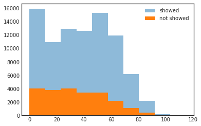

```python
plt.hist(df_clean.age[df_clean['showed'] == 1], alpha=.5, label='showed')
plt.hist(df_clean.age[df_clean['showed'] == 0], alpha=1, label='not showed')
plt.legend(loc='upper right')
plt.show()
```

most of the dataset population are on the younger side of the spectrum. This might be because of frequent checkups and vaccinations of children aged 10 and below.

### Gender:

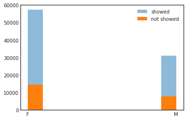

```python
plt.hist(df_clean.gender[df_clean['showed'] == 1], alpha=.5, label='showed')
plt.hist(df_clean.gender[df_clean['showed'] == 0], alpha=1, label='not showed')
plt.legend(loc='upper right')
plt.show()
```

Females are more common in this dataset, which could be caused by frequent checkups for females during pregnancy. However, the relationship between showing up to appointments and gender will be explored in the next steps.

### Other attributes:

distribution of Several health issues can be seen below. Hypertension is the most common one of them.

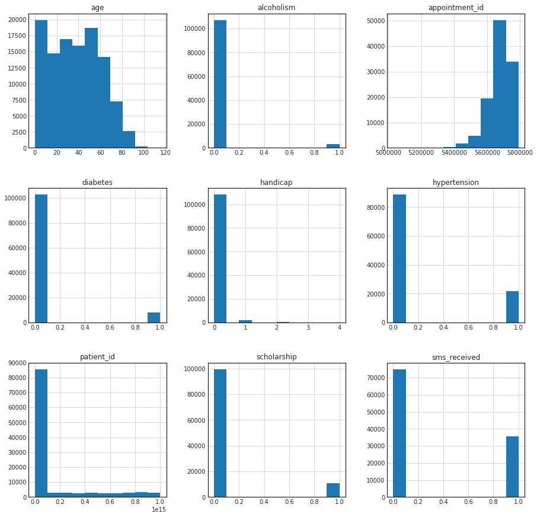

```python
df_clean.hist(figsize = (15,15));
```

```python
#checking number of people showing up to appointments
df_clean['showed'].value_counts()
```

```
1    88207
0    22319
Name: showed, dtype: int64
```

### Research Question 1: Do Male Miss Appointments more than Women

##### Start by counting showing up by gender. Then data was normalized by dividing count of attendance show-up of each gender by the total number of appointment of each gender

```python
counts_gender = df_clean.groupby(['gender','showed'])['appointment_id'].count()
totals_gender = df_clean.groupby(['gender'])['appointment_id'].count()
prop_gender = counts_gender / totals_gender
prop_gender
```

```
gender  showed
F       0         0.203149
        1         0.796851
M       0         0.199679
        1         0.800321
Name: appointment_id, dtype: float64
```

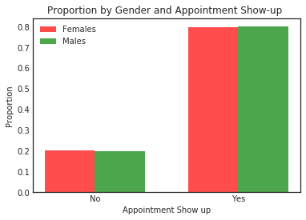

```python
ind = [0,1]  # the x locations for the groups
width = 0.35       # the width of the bars
# plot bars
female_bars = plt.bar(ind, prop_gender['F'], width, color='r', alpha=.7, label='Females')
male_bars = plt.bar([.35,1.35] , prop_gender['M'], width, color='g', alpha=.7, label='Males')

# title and labels
plt.ylabel('Proportion')
plt.xlabel('Appointment Show up')
plt.title('Proportion by Gender and Appointment Show-up ')
locations = ([.35/2,2.35/2]) # xtick locations
labels = ['No', 'Yes']  # xtick labels
plt.xticks(locations, labels)

# legend
plt.legend();
```

### Research Question 2: Does health status of the patient affect his probability of showing up

###### Start by creating a new column in the data frame to define sick persons. people who are diabetic, having high blood pressure, or handicapped were classified as having health issues.

```python
df_clean['sick'] = 0
```

```python
df_clean.sick[df_clean['handicap'] == 1] = 1
df_clean.sick[df_clean['hypertension'] == 1] = 1
df_clean.sick[df_clean['diabetes'] == 1] = 1
```

###### Below, proportion of sick people who showed up and missed the appointment to the sick population were calculated

```python
counts_sick = df_clean.groupby(['sick','showed'])['appointment_id'].count()
totals_sick = df_clean.groupby(['sick'])['appointment_id'].count()
prop_sick = counts_sick / totals_sick
prop_sick
```

```
sick  showed
0     0         0.209358
      1         0.790642
1     0         0.175698
      1         0.824302
Name: appointment_id, dtype: float64
```

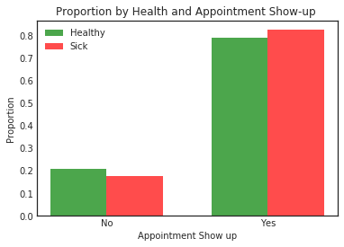

```python
ind = [0,1]  # the x locations for the groups
width = 0.35       # the width of the bars
# plot bars
healthy_bars = plt.bar(ind, prop_sick[0], width, color='g', alpha=.7, label='Healthy')
sick_bars = plt.bar([.35,1.35] , prop_sick[1], width, color='r', alpha=.7, label='Sick')

# title and labels
plt.ylabel('Proportion')
plt.xlabel('Appointment Show up')
plt.title('Proportion by Health and Appointment Show-up ')
locations = ([.35/2,2.35/2]) # xtick locations
labels = ['No', 'Yes']  # xtick labels
plt.xticks(locations, labels)

# legend
plt.legend();
```

###### Healthy individuals tend to miss more appointments than sick ones. This could be related to the urgency and the need of car that is more urgent in sick people (diabetic, high blood pressure, and handicapped). The relationship is not significant and might be due to the limitation of the dataset.

### Research Question 3: Does Reminding by SMS work?

[figure not shown]

```python
plt.hist(df_clean.sms_received[df_clean['showed'] == 1], alpha=.5, label='Showed')
plt.hist(df_clean.sms_received[df_clean['showed'] == 0], alpha=1, label='No Show')
# title and labels
plt.ylabel('Count of Appointments')
plt.xlabel('Received Reminder SMS')
plt.title('Count of people recevied SMS by Appointment Show-up ')
locations = ([.05,.95]) # xtick locations
labels = ['Yes', 'No']  # xtick labels
plt.xticks(locations, labels)

# legend
plt.legend(loc='upper right')
plt.show();
```

### Research Question 4: Does the time period between scheduling and the appointment affect the show up status?

###### We start by creating a column that calculates difference between the appointment day and the scheduled day

```python
df_clean['days_to_appointment'] = df_clean['appointment_day'] - df_clean['scheduled_day']
df_clean['days_to_appointment'] = df_clean['days_to_appointment'].dt.days
df_clean['days_to_appointment_bins'] = 0
```

###### Then we create several bins to show the trend of the relationship between the gap between the two dates and the no show status.

```python
df_clean.days_to_appointment_bins[df_clean['days_to_appointment'] <= 7] = '1 Week'
df_clean.days_to_appointment_bins[(df_clean['days_to_appointment'] <= 14) & (df_clean['days_to_appointment'] > 7)] = '2 Weeks'
df_clean.days_to_appointment_bins[(df_clean['days_to_appointment'] <= 21) & (df_clean['days_to_appointment'] > 14)] = '3 Weeks'
df_clean.days_to_appointment_bins[(df_clean['days_to_appointment'] <= 28) & (df_clean['days_to_appointment'] > 21)] = '4 Weeks'
df_clean.days_to_appointment_bins[(df_clean['days_to_appointment'] <= 60) & (df_clean['days_to_appointment'] > 28)] = '8 Weeks'
df_clean.days_to_appointment_bins[df_clean['days_to_appointment'] > 60] = '>12 Weeks'
```

###### The below code is to create a graph to show the relationship

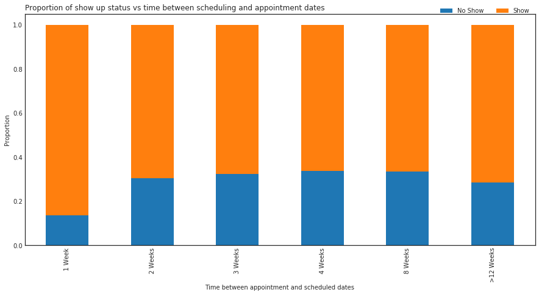

```python
counts_days_diff = df_clean.groupby(['days_to_appointment_bins','showed'])['appointment_id'].count()
totals_days_diff = df_clean.groupby(['days_to_appointment_bins'])['appointment_id'].count()
prop_days_diff = counts_days_diff/totals_days_diff

# plot data
fig, ax = plt.subplots(figsize=(15,7))
# use unstack()
prop_days_diff.unstack().plot(ax=ax, sort_columns=True, kind = 'bar', stacked = True)
h,l = ax.get_legend_handles_labels()
ax.legend(h[:2],["No Show", "Show"], loc='upper right', bbox_to_anchor=(1, 1.05),
          ncol=3)
plt.ylabel('Proportion')
plt.xlabel('Time between appointment and scheduled dates')
plt.title('Proportion of show up status vs time between scheduling and appointment dates',loc='left');
```

###### From the chart above, it can be seen some correlation between time between scheduling and appointment dates with the no show status. The closer the appointment to the scheduling date, the more likely the patient will make it to the appointment.

## Conclusions

### Limitations

1. Dataset might be biased to focus on no show side due to the scope and objective of collecting this data.
2. More explanation of information can be beneficial on drawing more accurate conclusions.

```python
#Creating html version of the notebook
from subprocess import call
call(['python', '-m', 'nbconvert', 'Investigate_a_Dataset.ipynb'])
```

```
0
```